# Exploratory Data Analysis

## Executive Summary

In the EDA part, we explored three questions. The topics included: Taylor Swift’s popularity on Reddit (based on the number of times Taylor Swift was mentioned), the distribution of Taylor Swift’s potential fans around the world (based on the language used in the subreddit), and the active fans related to Taylor Swift (analyze on the users). Data Cleaning was conducted before applying analysis. By understanding Taylor Swift’s mentions on Reddit over time, our team found that the number of mentions is relative to real-world events. When an album was released, or a concert was held by Taylor Swift, the mentions had a significant increase. It is also worth noting that the remastered albums are still popular. After that, our team viewed the language usage and the country mentioned in the Taylor Swift subreddit. The output revealed that Taylor Swift’s influence is concentrated in North America, Oceania, and Europe. And some non-English speakers from Europe are still engaged in the conversations. Finally, we investigated the active users related to Taylor Swift, the outcome showed that the number of posts is related to the number of scores that a Redditor can get, one who is active on Reddit, doing both posting and commenting is more likely to receive upvotes.

## Data Cleaning

[See the notebook](https://joycetaoyuuu.github.io/dsan-6000-project/eda_yt560.html)

During the data quality check prodecure, we removed `n/a` values, records outside the 2021-2023 period, and invalid month values (values greater than 12 or less than 1). For the text column, rows with `[removed]` and `[deleted]` values were eliminated since these records did not convey information. However, in the submission dataframe, we retained empty strings, as the absence of written content may still be associated with meaningful pictures or titles. Finally, for other variables, we removed invalid (negative) values. The final submissions dataframe has a shape of `391,059x12`, and the comments dataframe has a shape of `5,750,926x12`.

## Taylor Swift Mentions on Reddit Over Time with Trend

[See the notebook](https://joycetaoyuuu.github.io/dsan-6000-project/eda_mx109.html)

Figure 1 and Figure 2 represent the number of mentions trend in daily and monthly scales. From January 2021 to April 2023, the level of mentions of Taylor Swift on Reddit indicates strong interest, particularly during important moments in her career. `The data reveals that posts related to these moments experience spikes and variations, suggesting that they are influenced by real-time events`. The overall pattern of posts is quite volatile, with trend lines indicating fluctuating levels of engagement over time.

Notable events, such as the release of “Fearless (Taylor’s Version)” in April 2021 and “Red (Taylor’s Version)” in November 2021, sparked discussions about rights and demonstrated Swift’s ability to revisit her catalog with both critical acclaim and commercial success. `These re-recorded albums not only dominated the charts but also set new sales records, influencing broader conversations within the music industry`.

The peak in November 2022 coincided with a controversy surrounding Ticketmaster during the sale of tickets for Swift’s Era’s Tour. This incident generated a spike in mentions. The ticket sales debacle resulted in website crashes and poor customer service due to high demand, which garnered media coverage, ignited public debates, and even attracted government attention. This issue brings attention to the relationship between entertainment, business strategies, and government intervention, `demonstrating Swift's impact extending beyond the music sector`.

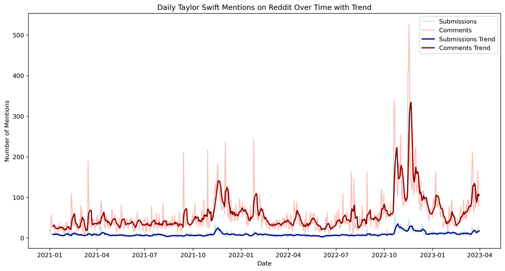

Figure 1: Daily Time Series Plot About Taylor Swift Mentions Over Time

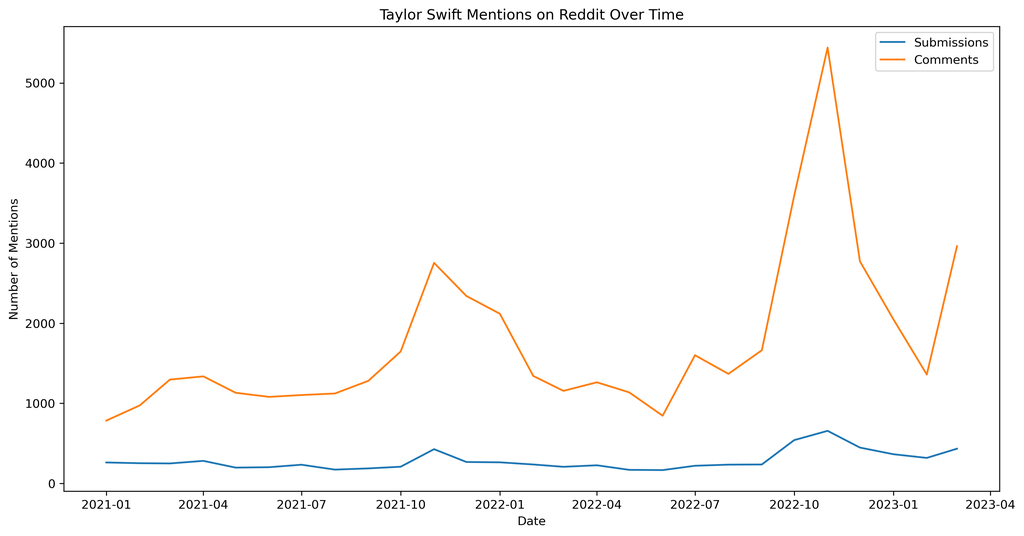

Figure 2: Monthly Time Series Plot About Taylor Swift Mentions Over Time

To gain an understanding of the discussions about Taylor Swift on Reddit, we can use sentiment analysis to determine the sentiment (positive, negative, or neutral) of these mentions.

By exploring the data from Reddit and interpreting Taylor Swift’s impact on the platform, we can see how her professional achievements and associated controversies resonate with the public. This showcases the range of her influence, which not only shapes cultural narratives and industry practices but also sparks political conversations. These aspects are vividly captured through social media engagement.

## Taylor Swift Fanbase Geographic & Language Usage Distribution

[See the notebook](https://joycetaoyuuu.github.io/dsan-6000-project/eda_yt560.html)

Table 1: Summary Table for Comments that Mentioned Countries

|  | Country Mentioned | Count | Percentage |
| --- | --- | --- | --- |
| 0 | Yes | 8,322 | 0.46 |
| 1 | No | 1,809,993 | 99.54 |

Table 2: Summary Table for Submissions that Mentioned Countries

|  | Country Mentioned | Count | Percentage |
| --- | --- | --- | --- |
| 0 | Yes | 343 | 0.84 |
| 1 | No | 40,421 | 99.16 |

Table 3: Top 20 Countries Mentioned under Taylor Swift Subreddit

| Countries | Count |
| --- | --- |
| Canada | 1,708 |
| Australia | 1,080 |
| Georgia | 624 |
| India | 449 |
| Ireland | 372 |
| Germany | 371 |
| France | 272 |
| Brazil | 261 |
| Jersey | 242 |
| Japan | 234 |
| Philippines | 218 |
| China | 212 |
| Mexico | 209 |
| United States | 190 |
| Argentina | 148 |
| New Zealand | 135 |
| Italy | 133 |
| Spain | 124 |
| Netherlands | 122 |
| Ukraine | 116 |

Table 1 and Table 2 illustrate the frequency and proportion of country mentions within the Taylor Swift subreddit. Despite the fact that this information is referenced in less than 1% of records, the count is close to 10,000. By extracting details about the mentioned countries, the Table 3 reveals the top 20 common countries mentioned in this subreddit. Canada as the most frequently referenced country, followed by Australia, and subsequently, Georgia and India. This analysis highlights that `Taylor Swift's influence in North America and Australia. In addition to English-speaking countries, she is also well-known in European countries`.

[interactive chart not shown]

Figure 3: Text Length and Score for Non-English Submissions

[interactive chart not shown]

Figure 4: Text Length and Score for Non-English Comments

Figure 3 and Figure 4 visually present the usage of languages other than English in the Taylor Swift subreddit. The radius of scatter plot represents the frequency of each language occurrence, the x-axis reflects the comment length, and the y-axis defines the average score. We found that German, Norwegian, French, and Afrikaans are the most prevalent non-English languages, with comments typically around 20 words, which is significantly briefer than English comments. Nevertheless, within non-English comments, these expressions maintain a notable length, reaching an average score of approximately 12. Obviously, the forum is predominantly used by English speakers, followed by users of European languages. `This analysis indicates that in a forum primarily dominated by English, users of European languages, while fewer in number, engage in conversations of relatively high quality`.

## Taylor Swift Fan Engagement Metrics

[See the code here](https://joycetaoyuuu.github.io/dsan-6000-project/eda_elliot.html)

**Top 15 Active Authors with Number of Posts**

[interactive chart not shown]

Figure 5: Top Active Authors with Number of Posts

**Top 15 Active Authors with Total Comments**

[interactive chart not shown]

Figure 6: Top Active Authors with Total Comments

**Top 15 Active Authors with Total Scores**

[interactive chart not shown]

Figure 7: Top Active Authors with Total Scores

Figure 5 shows the number of posts by author, with ‘lyu_lin’ leading by a significant margin over ‘wefoundwonderland13’ and ‘sampleswift’. Figure 6 depicts total comments by author; ‘lyu_lin’ again leads overwhelmingly, suggesting high engagement with their posts. Figure 7, total score by author, also sees ‘lyu_lin’ at the forefront, followed by ‘youAreASkyscraper’ and ‘gail1398’, indicating a strong correlation between the number of posts and the total score received. `It's notable that authors leading in one metric tend to lead in others, suggesting that quantity may correlate with higher engagement and scoring`.

[interactive chart not shown]

Figure 8: Top Active Authors in Comments

Figure 8 shows the number of comments per author, with ‘songacronymbot’ leading significantly, followed by ‘SwiftBot13’. The rest have notably fewer comments. The lower chart illustrates top upvoted comment scores by author. ‘culture_vulture_13’ has a far higher score than others, with ‘valek’ and ‘songacronymbot’ closely following. It’s interesting to note that while ‘songacronymbot’ has the most comments, it does not lead in upvoted comment scores, `indicating a potential difference in the quality of engagement or the type of content posted by different authors`.